# PREDICTIVE ANALYTICS MSBA 6420

## HW 4 : Part B

## 2. Dogs vs Cats Classification (50 points)

This is an Image classification exercise. We will play with an expired Kaggle competition, please follow the rule of Kaggle and check the following page for more information https://www.kaggle.com/c/dogsvs-cats/. After you make the prediction on the testing data, submit your prediction to Kaggle via late submission portal and show your team performance (Name formation of your team: MSBA.SessionX.Yourname, please replace X and Yourname with the correct string) using the screenshot on the Private Leaderboard, along with the description of your solutions and the codes (ipynb formation is highly encouraged) as the final submission.

#### Setting up the libraries and file structure:

```python
import os
import gc
import random
import re

import numpy as np
import pandas as pd
import glob
import matplotlib.pyplot as plt
import shutil
from tqdm import tqdm
import cv2
import time

from keras import backend
from keras.applications.inception_v3 import InceptionV3,preprocess_input
from keras.preprocessing.image import ImageDataGenerator
from keras.optimizers import SGD
from keras.models import Model, load_model
from keras.layers import Dense, GlobalAveragePooling2D
from keras.utils import to_categorical
```

[output not shown]

```python
#Defining labels for the classification
labels=['dog','cat']
```

Function to get the number of images in the directory

```python
def numberoffiles(path):
    if not os.path.exists(path):
        return 0
    return sum([len(files) for r, d, files in os.walk(path)])
```

```python
pwd
```

```
'/Users/aadarsh/Desktop/Carlson MSBA/Class assignments and quizzes/Fall/Predictive/Predictive HW4'
```

**Defining image resizing and batch_size parameters**

```python
#Setting Image and model parameters
img_width,img_height = 256,256
batch_size=30
Number_FC_Neurons=256
train_dir = 'dogs-vs-cats-redux-kernels-edition/train_dir'

total_samples = numberoffiles(train_dir)
val_split=0.3
n_train=total_samples*(1-val_split)
n_val=total_samples*val_split
num_classes = len(labels)
print(n_train,n_val)

gc.collect()
```

```
17500.699999999997 7500.299999999999
```

```
477
```

```python
# Define data pre-processing
train_image_gen = ImageDataGenerator(rescale=1/255,horizontal_flip=True,validation_split=val_split)
```

**Creating training and validation objects to store 70% and 30% images respectively**

```python
train_generator = train_image_gen.flow_from_directory(train_dir,target_size=(Image_width,Image_height),
                                                      batch_size=batch_size,seed=42,subset='training',shuffle=True,class_mode='binary')
val_generator = train_image_gen.flow_from_directory(train_dir,target_size=(Image_width,Image_height),
                                                    batch_size=batch_size,seed=42,subset='validation',shuffle=True,class_mode='binary')
```

```
Found 17500 images belonging to 2 classes.
Found 7500 images belonging to 2 classes.
```

Next, we load the model from Imagenet, that has been pretrained to work with the image datasets. The model consists of 308 layers in total, with repetitions of Convolutions, Poolingn and Normalization layers.

**Loading pretrained Inception model from imagenet along with the weights:**

```python
#Load the inception model and load with its pre trained weight
V3_base_model = InceptionV3(weights='imagenet', include_top=False)
print('Inception v3 base model without the last layer loaded')
```

```
Inception v3 base model without the last layer loaded
```

Using the GoogleLeNet architecture, we make use of the InceptionV3 pretrained model for our image classification exercsie. The main idea behind the inception models is to make use of parallel training of model for image features, so that it can save computational resources as well as feed of the performance and the training from the previous layer. It adds a set of 1x1, 3x3, 5x5 inception, pooling and reduce layers to offer the same deeper model performance in lower computational space.

**Adding final layers to the pretrained model to customize for the classification probelem of Cats and Dogs**

```python
x = V3_base_model.output
x_pool = GlobalAveragePooling2D()(x)
x_dense = Dense(Number_FC_Neurons,activation='relu')(x_pool)
final_pred = Dense(num_classes,activation='softmax')(x_dense)
model = Model(inputs=V3_base_model.input,outputs=final_pred)

model.summary()
```

```
Model: "model_8"
__________________________________________________________________________________________________
Layer (type)                    Output Shape         Param #     Connected to
==================================================================================================
input_6 (InputLayer)            (None, None, None, 3 0
__________________________________________________________________________________________________
conv2d_418 (Conv2D)             (None, None, None, 3 864         input_6[0][0]
__________________________________________________________________________________________________
batch_normalization_418 (BatchN (None, None, None, 3 96          conv2d_418[0][0]
__________________________________________________________________________________________________
activation_417 (Activation)     (None, None, None, 3 0           batch_normalization_418[0][0]
__________________________________________________________________________________________________
conv2d_419 (Conv2D)             (None, None, None, 3 9216        activation_417[0][0]
__________________________________________________________________________________________________
batch_normalization_419 (BatchN (None, None, None, 3 96          conv2d_419[0][0]
__________________________________________________________________________________________________
activation_418 (Activation)     (None, None, None, 3 0           batch_normalization_419[0][0]
__________________________________________________________________________________________________
conv2d_420 (Conv2D)             (None, None, None, 6 18432       activation_418[0][0]
__________________________________________________________________________________________________
batch_normalization_420 (BatchN (None, None, None, 6 192         conv2d_420[0][0]
__________________________________________________________________________________________________
activation_419 (Activation)     (None, None, None, 6 0           batch_normalization_420[0][0]
__________________________________________________________________________________________________
max_pooling2d_20 (MaxPooling2D) (None, None, None, 6 0           activation_419[0][0]
__________________________________________________________________________________________________
conv2d_421 (Conv2D)             (None, None, None, 8 5120        max_pooling2d_20[0][0]
__________________________________________________________________________________________________
batch_normalization_421 (BatchN (None, None, None, 8 240         conv2d_421[0][0]
__________________________________________________________________________________________________
activation_420 (Activation)     (None, None, None, 8 0           batch_normalization_421[0][0]
__________________________________________________________________________________________________
conv2d_422 (Conv2D)             (None, None, None, 1 138240      activation_420[0][0]
__________________________________________________________________________________________________
batch_normalization_422 (BatchN (None, None, None, 1 576         conv2d_422[0][0]
__________________________________________________________________________________________________
activation_421 (Activation)     (None, None, None, 1 0           batch_normalization_422[0][0]
__________________________________________________________________________________________________
max_pooling2d_21 (MaxPooling2D) (None, None, None, 1 0           activation_421[0][0]
__________________________________________________________________________________________________
```

[output cut: 616 more lines]

```
mixed10 (Concatenate)           (None, None, None, 2 0           activation_502[0][0]
                                                                 mixed9_1[0][0]
                                                                 concatenate_10[0][0]
                                                                 activation_510[0][0]
__________________________________________________________________________________________________
global_average_pooling2d_8 (Glo (None, 2048)         0           mixed10[0][0]
__________________________________________________________________________________________________
dense_15 (Dense)                (None, 256)          524544      global_average_pooling2d_8[0][0]
__________________________________________________________________________________________________
dense_16 (Dense)                (None, 2)            514         dense_15[0][0]
==================================================================================================
Total params: 22,327,842
Trainable params: 22,293,410
Non-trainable params: 34,432
__________________________________________________________________________________________________
```

**Adding model refinements with loss functions and optimizer**

```python
#Fine tune model by retraining the few end layers of the inception model

layers=154
for layer in model.layers[:layers]:
    layer.trainable =False
for layer in model.layers[layers:]:
    layer.trainable=True

    sgd = SGD(lr = 0.01, decay = 1e-6, momentum = 0.9, nesterov = True)
model.compile(optimizer=sgd,loss='binary_crossentropy',metrics=['accuracy'])
```

**Nesterov Accelerated Gradient** helps to arrive at the local optimum (minima) much faster than the normal gradient boosting, by estimating the direction in which it should approch in the next iteration. We make use of NAG to speed up the loss minimization while still following the gradient descent methodology.

Since our problem involves only two classes, we can assume the binary cross entropy function to give us accurate loss value and we do not have to look for categorical cross entropy. The same is seen in the performance of model.

**Model Fitting with training data and Validation on validation set**

```python
history_learning = model.fit_generator(train_generator,epochs=1,
                                                steps_per_epoch=n_train//batch_size,
                                                validation_data=val_generator,
                                                validation_steps=n_val//batch_size,
                                                verbose=1,
                                                callbacks=callback,
                                                class_weight='auto')
model.save('model.hd5')
```

[output not shown]

```python
gc.collect()
```

```
1255
```

```python
#Checking model accuracy on validation set:
score = model.evaluate_generator(val_generator,verbose=1)
print('Validation loss: ', score[0])
print('Validation accuracy', score[1])
```

```
Validation loss:  0.002772111911326647
Validation accuracy 0.9865333437919617
```

**Working on Test Data**

```python
## Predicting and comparing with Test


test_dir = 'dogs-vs-cats-redux-kernels-edition/test_dir'
```

```python
# Generating and preprocessing test data for prediction


test_image_gen = ImageDataGenerator(rescale=1/255)
test_generator = test_image_gen.flow_from_directory(test_dir,target_size=(Image_width,Image_height),
                                                    batch_size=1,seed=42,class_mode=None,shuffle=False)
```

```
Found 12500 images belonging to 1 classes.
```

```python
y_pred = model.predict_generator(generator=test_generator,verbose=1)
```

### Preparing outputs for submission

```python
submission = pd.DataFrame({'id':pd.Series(test_generator.filenames),
                           'label':pd.Series(y_pred.clip(min = 0.02, max = 0.98)[:,1])})

submission['id'] = submission.id.str.extract('(\d+)')
submission['id'] = pd.to_numeric(submission['id'])
submission['label'] = submission['label'].round(6)

submission.loc[0:25]
```

|  | id | label |
| --- | --- | --- |
| 0 | 1 | 0.980000 |
| 1 | 10 | 0.020000 |
| 2 | 100 | 0.020000 |
| 3 | 1000 | 0.980000 |
| 4 | 10000 | 0.959592 |
| 5 | 10001 | 0.020000 |
| 6 | 10002 | 0.020000 |
| 7 | 10003 | 0.980000 |
| 8 | 10004 | 0.980000 |
| 9 | 10005 | 0.020000 |
| 10 | 10006 | 0.020000 |
| 11 | 10007 | 0.020000 |
| 12 | 10008 | 0.020000 |
| 13 | 10009 | 0.020000 |
| 14 | 1001 | 0.020000 |
| 15 | 10010 | 0.980000 |
| 16 | 10011 | 0.980000 |
| 17 | 10012 | 0.020000 |
| 18 | 10013 | 0.020000 |
| 19 | 10014 | 0.020000 |
| 20 | 10015 | 0.980000 |
| 21 | 10016 | 0.020000 |
| 22 | 10017 | 0.020000 |
| 23 | 10018 | 0.020000 |
| 24 | 10019 | 0.020000 |
| 25 | 1002 | 0.980000 |

**Viewing the predictions**

Sample test image :

```python
images=glob.glob("dogs-vs-cats-redux-kernels-edition/test_dir/test/*.jpg")
```

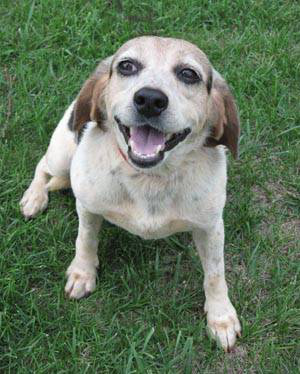

```python
Image.open(images[110])
```

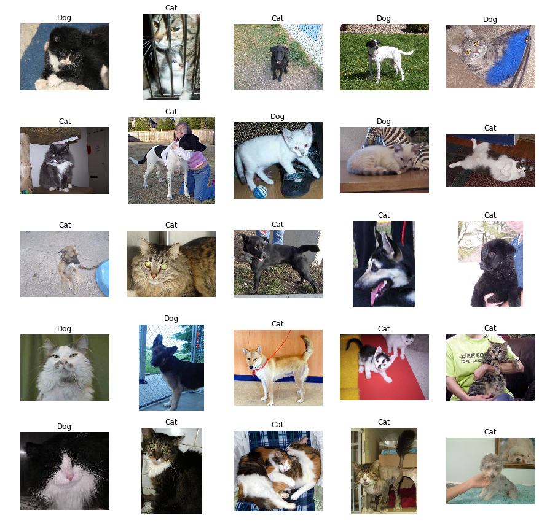

```python
import glob
from PIL import Image


images=glob.glob("dogs-vs-cats-redux-kernels-edition/test_dir/test/*.jpg")
fig,ax = plt.subplots(5,5, figsize=(15,15))
for i,fn in enumerate(test_generator.filenames[:25]):

    ax[i//5, i%5].imshow(Image.open(images[i]))
    ax[i//5, i%5].axis('off')

    if (submission['label'][i]) > 0.5:
        label='Dog'
    elif (submission['label'][i])<0.5:
            label='Cat'
    ax[i//5, i%5].set_title(label)
plt.show()
```

Writing to disk for submission:

```python
submission.to_csv('MSBA.Session1.AadarshGupta_submission1.csv',index=False)
```

#### Kaggle Submissions

On uploading to the Kaggle Competitions page, the output model achieves a score of 2.87.

To improve this score, **we increase the number of epochs in our model to 5** and train it on the Kaggle Platform directly to utilize the GPU strength

We also use more layers in the model (from the Inception pretrained space) and thereby, more parameters to help with the accuracy.

In the final model, the number of neurons were changed from 1024 to 256, and the image resolution from 320x320 to 256x256.

The final score received from our best model submission to Kaggle gives out a score of **0.0510**

The same can be seen below :

[figure not shown]

```python
screenShot = '/Users/aadarsh/Desktop/Screen Shot 2019-11-24 at 11.19.38 PM.png'

Image.open(screenShot)
```

> End